# Chap 3: xxx

## 3.4 Annotating plot

R graphics in general is fundamentally oriented to supporting the annotation of plots. The regions and coordinate systems used in the construction of a plot remain available for adding further output to the plot. For example, it is possible to position a text label relative to the scales on the axes of a plot.

### 3.4.1 Annotating the plot region

Most low-level graphics functions that add output to an existing plot, add the output to the plot region. In other words, locations are specified relative to the user coordinate system.

#### Graphical primitives

The most common use of this facility is to add extra sets of data to a plot. The `lines()` function draws lines between (x, y) locations, and the `points()` function draws data symbols at (x, y) locations.

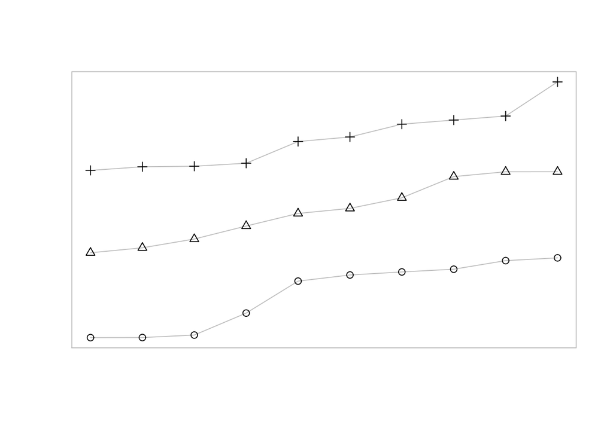

```r
x <- 1:10
y <- matrix(sort(rnorm(30)), ncol=3)
plot(x, y[,1], ylim=range(y), ann=FALSE, axes=FALSE, type="l", col="gray")
box(col="gray")
points(x, y[,1])
lines(x, y[,2], col="gray")
points(x, y[,2], pch=2)
lines(x, y[,3], col="gray")
points(x, y[,3], pch=3)
```

A set of points are added for the first set of y-values, then lines and points are added for the other two sets of y-values.

It is also possible to draw text at (x, y) locations with the `text()` function. This is useful for labeling data locations, particularly using the pos argument to offset the text so that it does not overlay the corresponding data symbols.

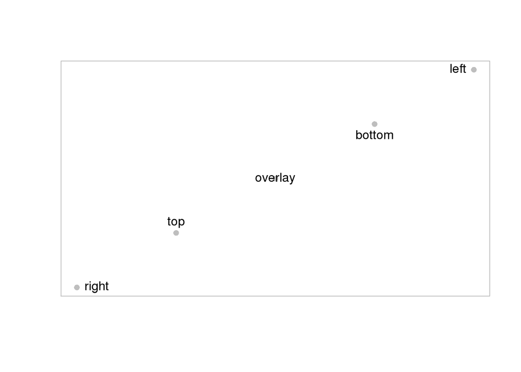

```r
x <- 1:5
y <- x
plot(x, y, ann=FALSE, axes=FALSE, col="gray", pch=16)
box(col="gray")
text(x[-3], y[-3], c("right", "top", "bottom", "left"), pos=c(4, 3, 1, 2))
text(3, 3, "overlay")
```

Like the `plot()` function, the `text()`, `lines()`, and `points()` functions are generic. For example, both `lines()`, and `points()` will accept formulae for specifying the (x, y) locations.

The `text()` function normally takes a character value to draw, but it will also accept an R expression (as produced by the `expression()` function), which can be used to produce a mathematical formula with special symbols.

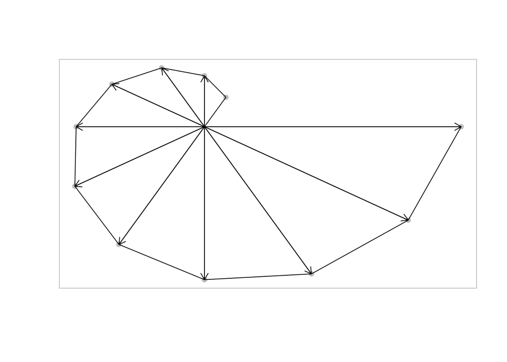

```r
t <- seq(60, 360, 30)
x <- cos(t/180*pi)*t/360
y <- sin(t/180*pi)*t/360
plot(x, y, ann=FALSE, axes=FALSE, col="gray", pch=16)
box(col="gray")
lines(x, y)
segments(0, 0, x, y)
arrows(0, 0, x[-1], y[-1], length=.1)
```

Let’s look at splines:

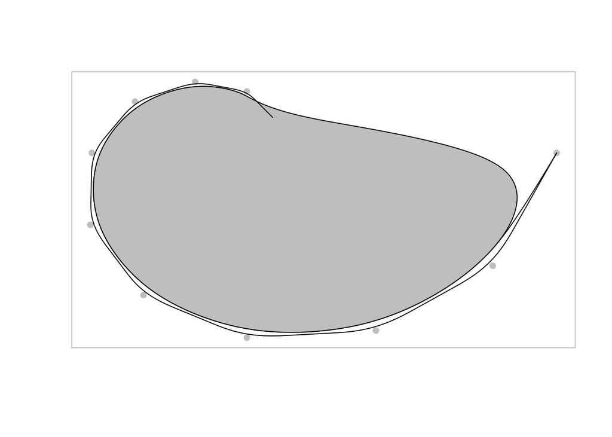

```r
plot(x, y, ann=FALSE, axes=FALSE, col="gray", pch=16)
box(col="gray")
xspline(x, y, shape=1)
xspline(x, y, shape=1, open=FALSE, col="gray")
xspline(x, y, shape=0.35)
```

And polygons:

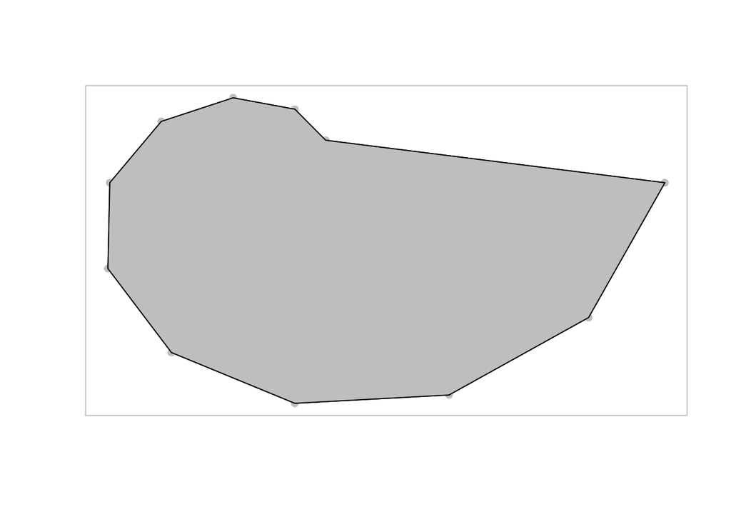

```r
plot(x, y, ann=FALSE, axes=FALSE, col="gray", pch=16)
box(col="gray")
polypath(c(x, NA, .5*x), c(y, NA, .5*y), col="gray", rule="evenodd")
polygon(x, y, col="gray")
```

#### Graphical utilities

There are a number of utility functions that provide slightly more complex shapes. The `grid()` function adds a series of grid lines to a plot, i.e., a series of line segments.

The `abline()` function provides a number of convenient ways to add a line (or lines) to a plot. The line(s) can be specified either by a slope and y-axis intercept, or as a series of x-locations for vertical lines or as a series of y-locations for horizontal lines.

Generate some data and fit the least square line:

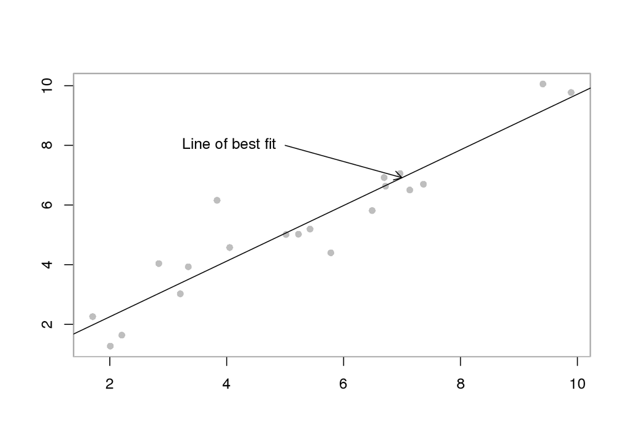

```r
x <- runif(20, 1, 10)
y <- x + rnorm(20)
plot(x, y, ann=FALSE, col="gray", pch=16)
box(col="gray")
lmfit <- lm(y ~ x)
abline(lmfit)
arrows(5, 8, 7, predict(lmfit, data.frame(x=7)), length=0.1)
text(5, 8, "Line of best fit", pos=2)
```

The `rug()` function produces a “rug” plot along one of the axes, which consists of a series of tick marks representing data locations.

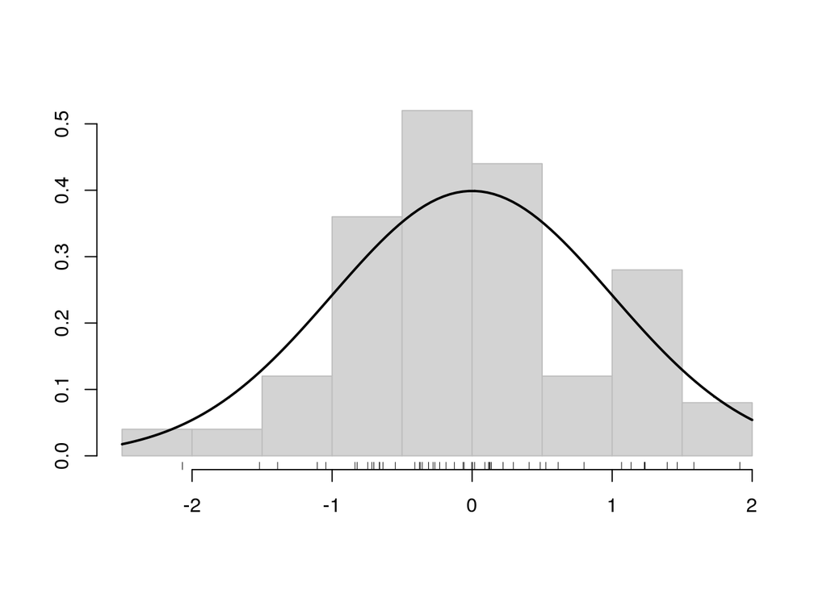

```r
y <- rnorm(50)
hist(y, freq=FALSE, main="", xlab="", ylab="", border="gray", col="light gray")
rug(y, ticksize=0.02)
curve(dnorm(x), lwd=2, add=TRUE)
```

#### Missing values and non-finite values

R has special values representing missing observations (`NA`) and non-finite values (`NaN` and `Inf`). Most traditional graphics functions allow such values within (x, y) locations and handle them by not drawing the relevant location. For drawing lines, this means that lines to or from the relevant location are not drawn; a gap is created in the line.

### 3.4.2 Annotating the margins

The `mtext()` function draws text at any location in any of the margins. The `outer` argument controls whether output goes in the figure or outer margins. The `side` argument determines which margin to draw in: 1 means the bottom margin, 2 means the left margin, 3 means the top margin, and 4 means the right margin.

In the figure margins, the location of the text along the margin can be specified relative to the user coordinates on the relevant axis using the `at` argument.

The `title()` function is essentially a specialized version of `mtext()`.

The following code demonstrates the use of `mtext()` and a simple application of using `lines()` outside the plot region for drawing what appears to be a rectangle extending across two plots. The clipping region is set to the entire device using `xpd=NA`.

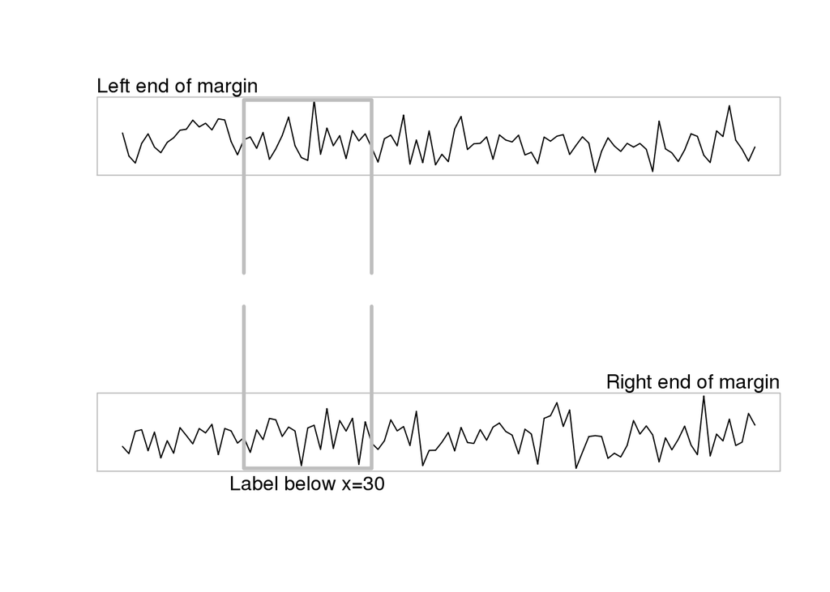

```r
y1 <- rnorm(100)
y2 <- rnorm(100)
par(mfrow=c(2, 1), xpd=NA)

plot(y1, type="l", axes=FALSE, xlab="", ylab="", main="")
box(col="gray")
mtext("Left end of margin", adj=0, side=3)
lines(x=c(20, 20, 40, 40), y=c(-9, max(y1), max(y1), -9), lwd=3, col="gray")

plot(y2, type="l", axes=FALSE, xlab="", ylab="", main="")
box(col="gray")
mtext("Right end of margin", adj=1, side=3)
mtext("Label below x=30", at=30, side=1)
lines(x=c(20, 20, 40, 40), y=c(9, min(y2), min(y2), 9), lwd=3, col="gray")
```

### 3.4.3 Legends

The traditional graphics system provides the legend() function for adding a legend or key to a plot. The legend is usually drawn within the plot region, and is located relative to user coordinates.

A scatterplot with a legend to relate group names to different symbols:

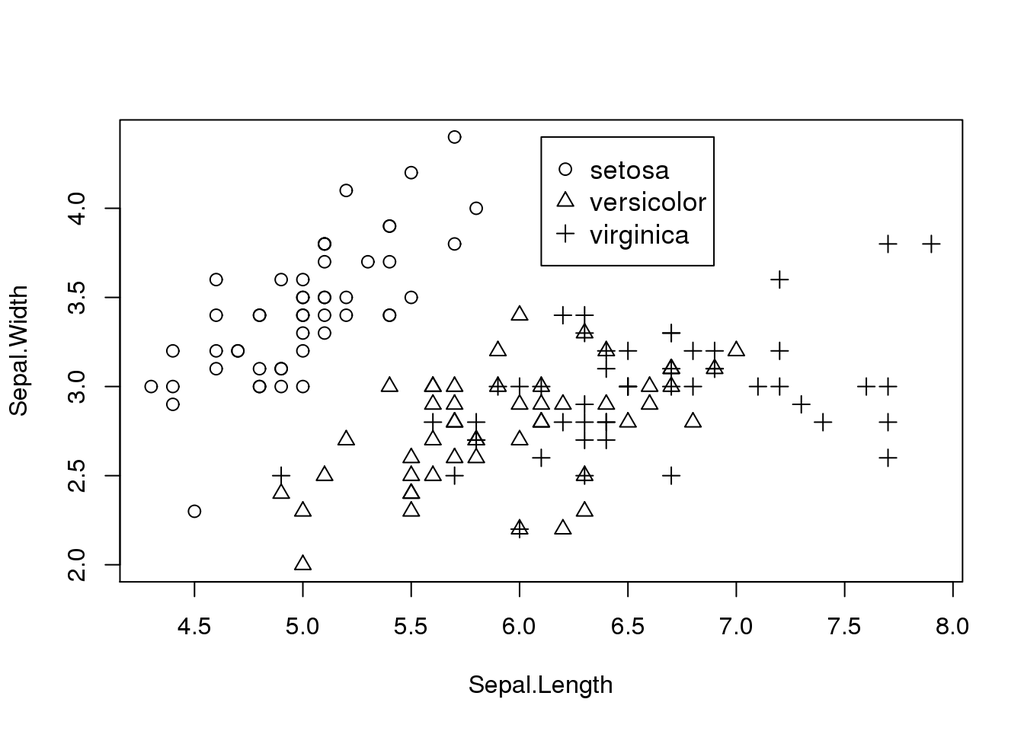

```r
par(mfrow=c(1,1))
with(iris,
     plot(Sepal.Length, Sepal.Width, pch=as.numeric(Species), cex=1.1))
legend(6.1, 4.4, c("setosa", "versicolor", "virginica"), cex=1.1, pch=1:3)
```

A barplot with a legend to relate group names to different fill patterns:

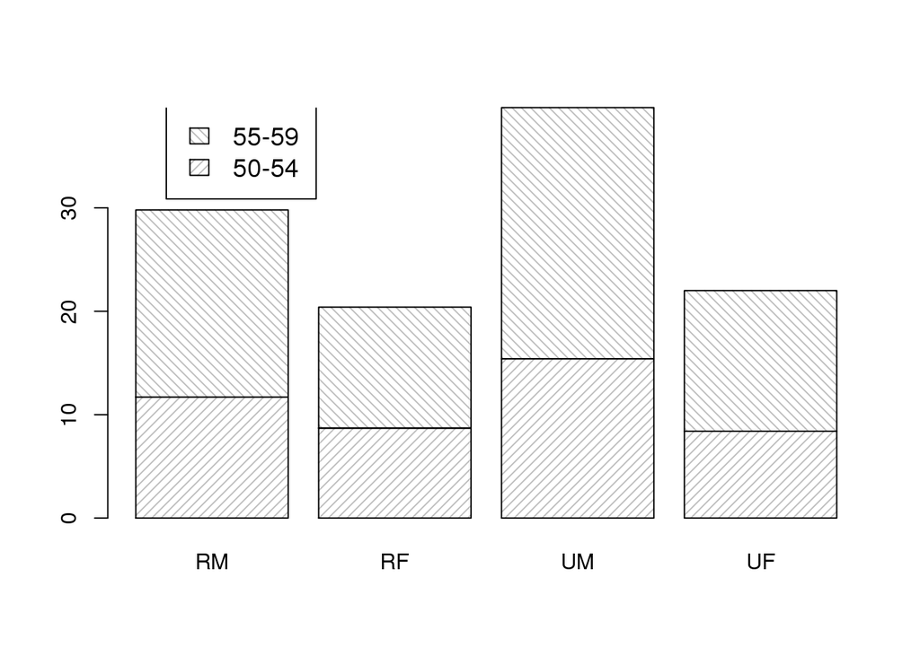

```r
barplot(VADeaths[1:2,], angle=c(45, 135), density=20, col="gray",
        names=c("RM", "RF", "UM", "UF"))
legend(0.4, 40, c("55-59", "50-54"), cex=1.2,
       angle=c(135, 45), density=20, fill="gray")
```

### 3.4.4 Axes

In most cases, the axes that are automatically generated by the traditional graphics system will be sufficient for a plot. The user can inhibit the production of the automatic axis and draw a customized axis using the `axis()` function.

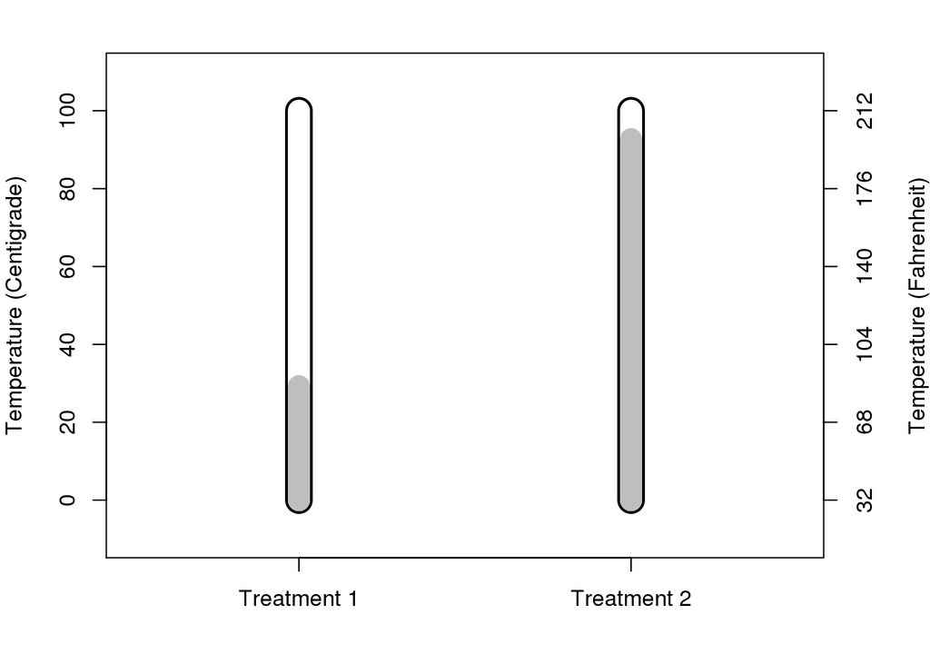

```r
x <- 1:2
y <- runif(2, 0, 100)
par(mar=c(4, 4, 2, 4))
plot(x, y, type="n", xlim=c(0.5, 2.5), ylim=c(-10, 110), axes=FALSE, ann=FALSE)
axis(2, at=seq(0, 100, 20))
mtext("Temperature (Centigrade)", side=2, line=3)
axis(1, at=1:2, labels=c("Treatment 1", "Treatment 2"))
axis(4, at=seq(0, 100, 20), labels=seq(0, 100, 20)*9/5 + 32)
mtext("Temperature (Fahrenheit)", side=4, line=3)
box()
segments(x, 0, x, 100, lwd=20)
segments(x, 0, x, 100, lwd=16, col="white")
segments(x, 0, x, y, lwd=16, col="gray")
```

The `axis()` function is not generic, but there are special alternative functions for plotting time-related data. The functions `axis.Date()` and `axis.POSIXct()` take an object containing dates and produce an axis with appropriate labels representing times, days, months, and years.

### 3.4.5 Coordinate systems

The traditional graphics system provides a number of coordinate systems for conveniently locating graphical output. Graphical output in the plot region is automatically positioned relative to the scales on the axes and text in the figure margins is placed in terms of a number of lines away from the edge of the plot.

The traditional graphics state can be queried to determine features of existing coordinate systems, then new coordinate systems can be calculated from this information.

`par()` can also be used to query current graphics state settings. The most useful settings are: `din`, `fin`, and `pin`, which reflect the current size, (`width`, `height`), of the graphics device, figure region, and plot region, in inches; and usr, which reflects the current user coordinate system (i.e., the ranges on the axes). The values of `usr` are in the order (`xmin`, `xmax`, `ymin`, `ymax`).

#### Overlaying output

We cam plot two data sets on the same plot where the data sets share a common x-variable, but have very different y-scales.

The data are yearly numbers of drunkenness-related arrests∗ and mean annual temperature in New Haven, Connecticut from 1912 to 1971. The temperature data are available as the data set `nhtemp` in the `datasets` package.

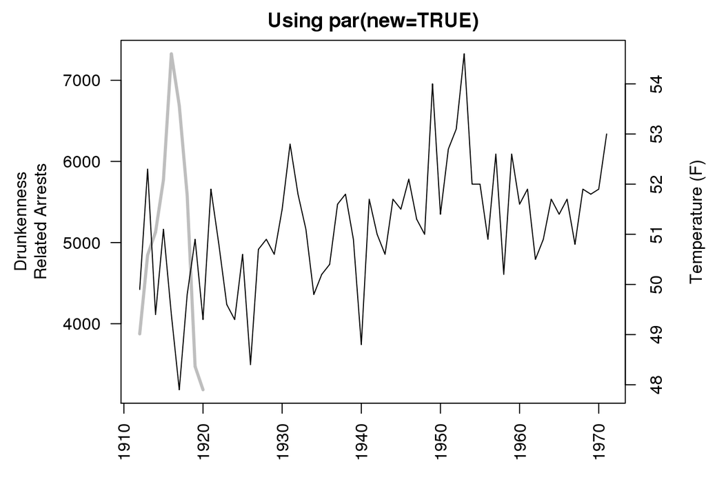

```
## logical(0)
```

```r
drunkenness <- ts(c(3875, 4846, 5128, 5773, 7327, 6688, 5582, 3473, 3186,
                    rep(NA, 51)), start=1912, end=1971)
par(mar=c(5, 6, 2, 4))
plot(drunkenness, lwd=3, col="gray", ann=FALSE, las=2)
mtext("Drunkenness\nRelated Arrests", side=2, line=3.5)
par(new=TRUE)
plot(nhtemp, ann=FALSE, axes=FALSE)
mtext("Temperature (F)", side=4, line=3)
title("Using par(new=TRUE)") > axis(4)
```

Or:

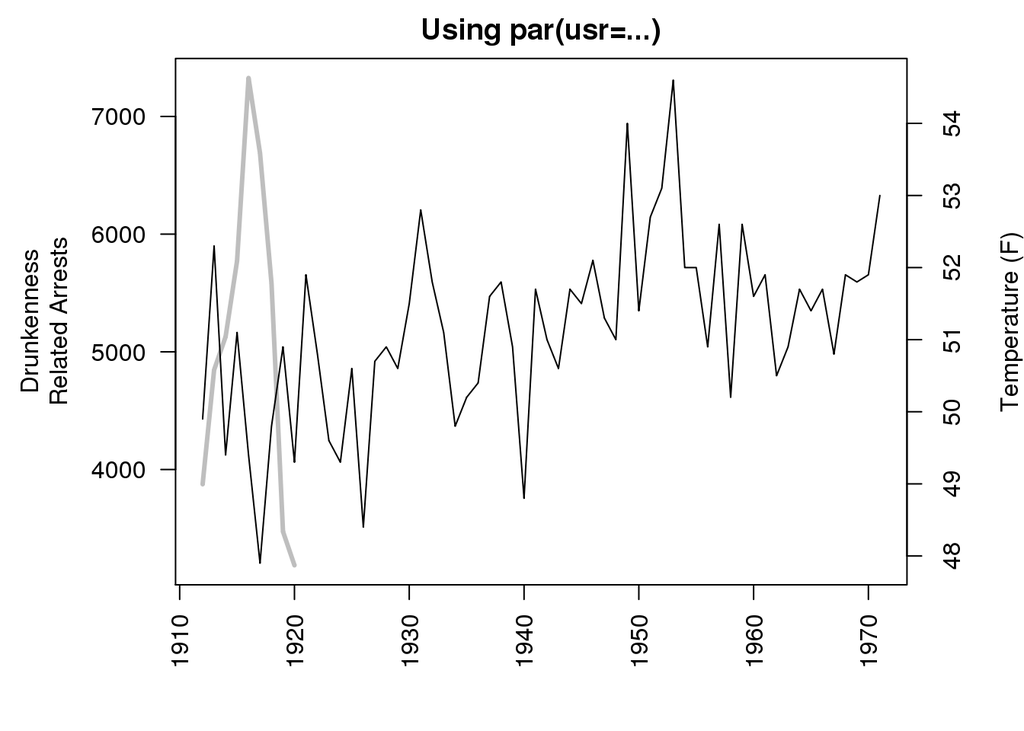

```r
par(mar=c(5, 6, 2, 4))
plot(drunkenness, lwd=3, col="gray", ann=FALSE, las=2)
mtext("Drunkenness\nRelated Arrests", side=2, line=3.5)
usr <- par("usr")
par(usr=c(usr[1:2], 47.6, 54.9))
lines(nhtemp)
mtext("Temperature (F)", side=4, line=3)
title("Using par(usr=...)")
axis(4)
```

The following code shows the symbols() function being used to annotate a basic scatterplot:

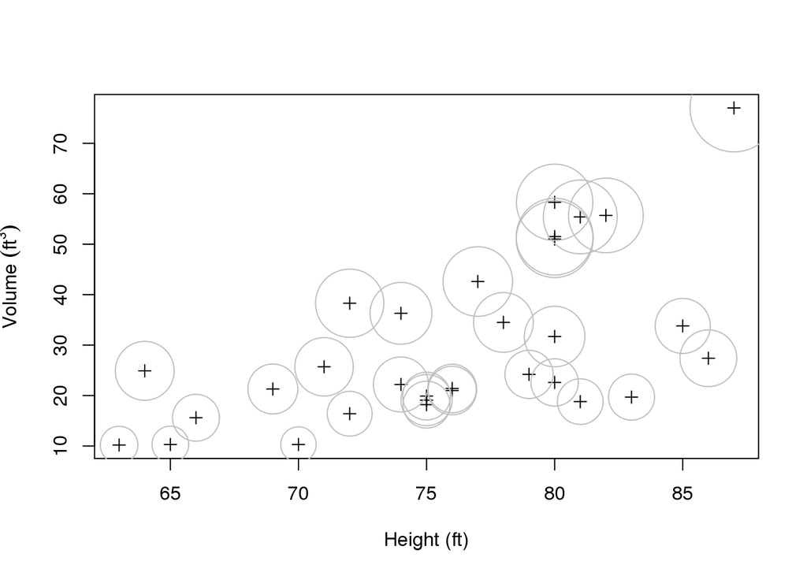

```r
with(trees,
     {plot(Height, Volume, pch=3, xlab="Height (ft)",
           ylab=expression(paste("Volume ", (ft^3))))
      symbols(Height, Volume, circles=Girth/12, fg="gray", inches=FALSE, add=TRUE)
      })
```

### 3.4.6 Special cases

#### Obscure scales on axes

The following code provides a simple example of annotating boxplots to add a jittered dotplot of individual data points on top of the boxplots.

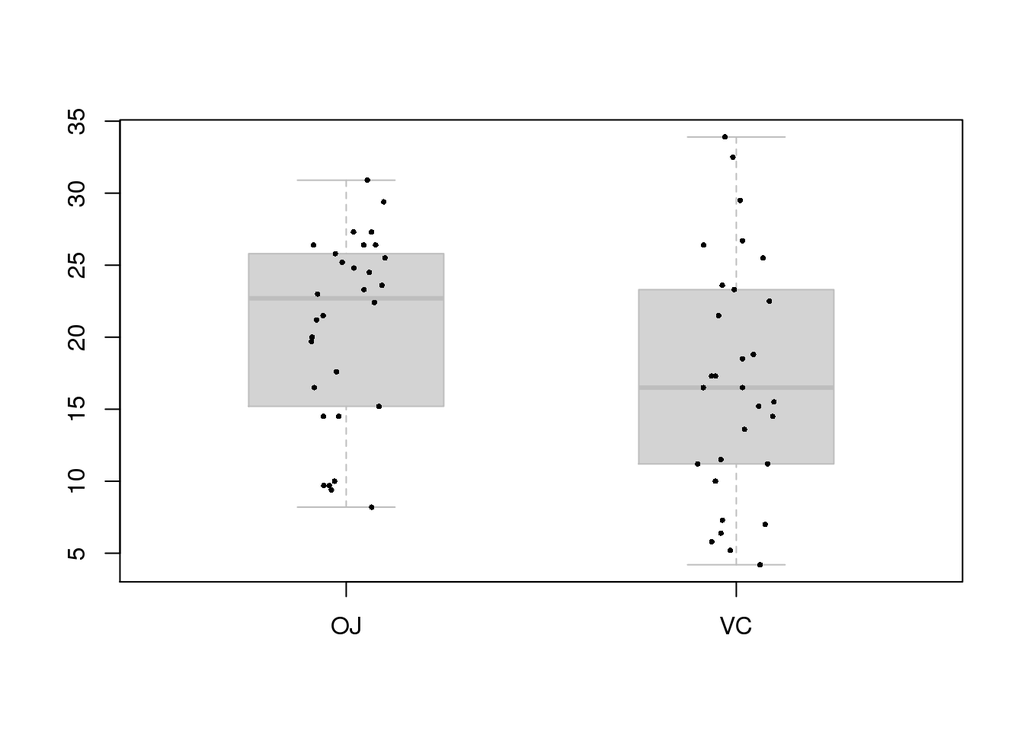

```r
with(ToothGrowth, {
  boxplot(len ~ supp, border="gray", col="light gray", boxwex=0.5)
  points(jitter(rep(1:2, each=30), 0.5), unlist(split(len, supp)),cex=0.5, pch=16)
  })
```

#### Functions that draw several plots

The pairs() function is an example of a high-level function that draws more than one plot. This function draws a matrix of scatterplots. This function saves the traditional graphics state before drawing, call `par(mfrow)` or `layout()` to arrange the individual plots, and restore the traditional graphics state once all of the individual plots have been drawn.

The `pairs()` function has a number of arguments that allow the user to specify a function: `panel`, `diag.panel`, `upper.panel`, `lower.panel`, and `text.panel`.

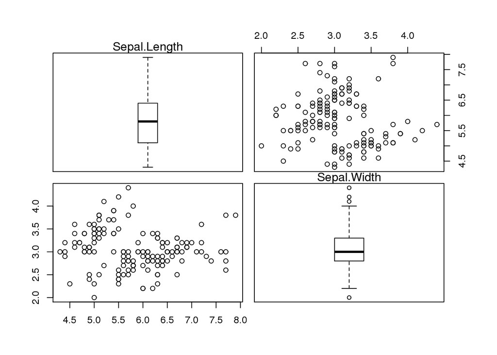

```r
pairs(iris[1:2],
      diag.panel=function(x, ...) {
        boxplot(x, add=TRUE, axes=FALSE, at=mean(par("usr")[1:2]))
        },
      text.panel=function(x, y, labels, ...) {
        mtext(labels, side=3, line=0)
        })
```

#### 3D plots

It is possible to annotate a plot that was produced using the `persp()` function, The important step is to acquire the transformation matrix that the `persp()` function returns. This can be used to transform 3D locations into 2D locations, using the `trans3d()` function. The result can then be given to the standard anno- tation functions such as `lines()` and `text()`.

The `persp()` function also has an `add` argument, which allows multiple `persp()` plots to be over-plotted.

The following code demonstrates annotation of `persp()` output to add a contour plot beneath a 3D plot of the Maunga Whau volcano in Auckland, New Zealand. The data are from the `volcano` matrix in the `datasets` package.

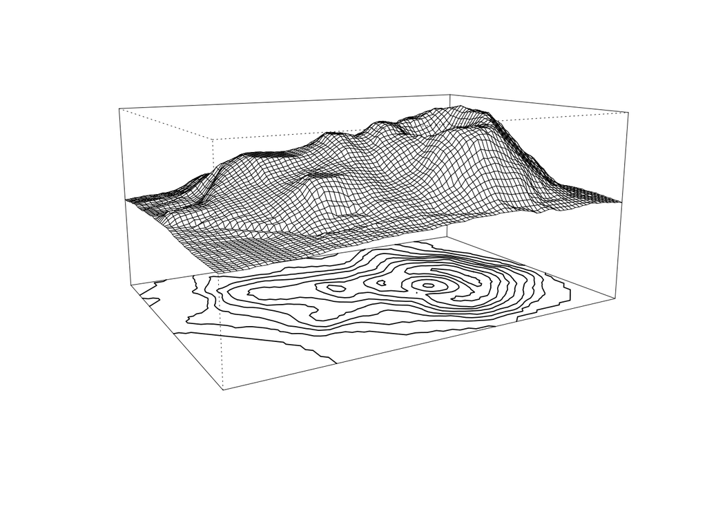

```r
z <- 2 * volcano
x <- 10 * (1:nrow(z))
y <- 10 * (1:ncol(z))
trans <- persp(x, y, z, zlim=c(0, max(z)),
               theta = 150, phi = 12, lwd=.5, scale = FALSE, axes=FALSE)
clines <- contourLines(x, y, z)
lapply(clines,
       function(contour) { lines(trans3d(contour$x, contour$y, 0, trans))
                           })
```